# Flexible Damage Functions

Year 2098 · T<sub>mean</sub> across these regions: 2.05°C

| Region | Raw | Flex | Residual |
| --- | --- | --- | --- |
| FJI.R13886963f95ae1bc | 0 | 0 | 0 |
| TUV.R06fb643237e8113e | 0 | 0 | 0 |
| USA.1.9 | -0.36 | -0.36 | 1.97e-6 |
| USA.50.3050 | -0.291 | -0.291 | 3.16e-6 |
| PAK.5.13.54 | -0.118 | -0.118 | -3.52e-6 |
| AUS.11.1276 | -0.173 | -0.684 | -0.511 |
| AUS.11.1302 | -0.197 | -0.707 | -0.51 |
| AUS.11.1376 | -0.206 | -0.707 | -0.501 |
| PHL.Rfb548f506b985526 | 0.0951 | 0.587 | 0.492 |
| PHL.41 | 0.083 | 0.565 | 0.482 |

**rcp85**

**SSP2**

**high**

**Correlation:** 0.9553 | **RMSE:** 0.111964 | **Sign agreement:** 96.9%

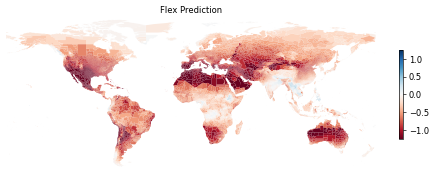

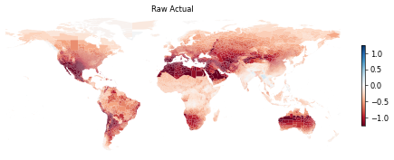

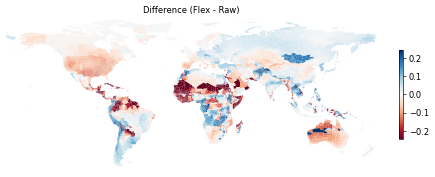

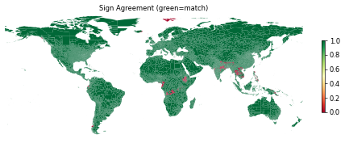

[interactive chart not shown]

Top 5 best predicted Top 5 worst predicted

Year 2098 · T<sub>mean</sub> across these regions: 4.51°C

| Region | Raw | Flex | Residual |
| --- | --- | --- | --- |
| FJI.R13886963f95ae1bc | 0 | 0 | 0 |
| TUV.R06fb643237e8113e | 0 | 0 | 0 |
| IND.21.322.1292 | -0.0737 | -0.0737 | -3.06e-6 |
| GBR.4.171 | -0.238 | -0.238 | 1.03e-5 |
| IND.31.466.1879 | -0.54 | -0.54 | -1.32e-5 |
| OMN.6 | -0.678 | -1.46 | -0.778 |
| ETH.10.57.R0aa5fd76345b0e2d | -0.347 | 0.346 | 0.693 |
| SYR.14.58 | -0.363 | -1.05 | -0.689 |
| SYR.14.59 | -0.361 | -0.986 | -0.625 |
| LCA.R3eb241720effe7f4 | -0.39 | -1.01 | -0.623 |

**low**

**Correlation:** 0.9617 | **RMSE:** 0.105803 | **Sign agreement:** 98.0%

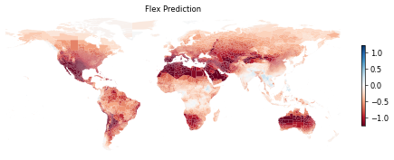

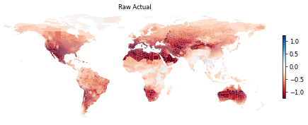

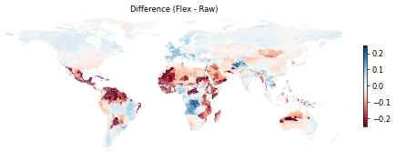

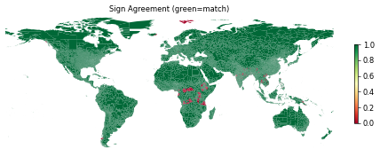

[interactive chart not shown]

Top 5 best predicted Top 5 worst predicted

Year 2098 · T<sub>mean</sub> across these regions: 4.51°C

| Region | Raw | Flex | Residual |
| --- | --- | --- | --- |
| FJI.R13886963f95ae1bc | 0 | 0 | 0 |
| TUV.R06fb643237e8113e | 0 | 0 | 0 |
| COL.7.330 | -0.395 | -0.395 | -2.36e-7 |
| RUS.49.1163.1280 | -0.481 | -0.481 | 5.19e-6 |
| IND.33.529.2117 | -0.156 | -0.156 | 1.02e-5 |
| TUR.48.R5570f5f28e7b75f0 | -0.864 | -1.6 | -0.736 |
| SOM.14.54 | -0.152 | -0.776 | -0.624 |
| SOM.15.57 | -0.168 | -0.79 | -0.622 |
| PSE.2.6 | -0.433 | -1.03 | -0.594 |
| BRA.5.R111a8142c02ae043 | -0.494 | -1.09 | -0.593 |

**SSP3**

**high**

**Correlation:** 0.9725 | **RMSE:** 0.164938 | **Sign agreement:** 97.3%

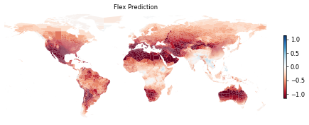

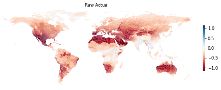

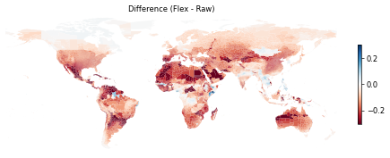

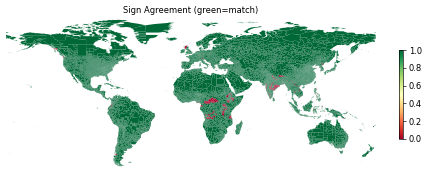

[interactive chart not shown]

Top 5 best predicted Top 5 worst predicted

Year 2098 · T<sub>mean</sub> across these regions: 4.51°C

| Region | Raw | Flex | Residual |
| --- | --- | --- | --- |
| FJI.R13886963f95ae1bc | 0 | 0 | 0 |
| TUV.R06fb643237e8113e | 0 | 0 | 0 |
| IND.33.540.2147 | -0.124 | -0.124 | 4.34e-5 |
| IND.21.334.1410 | -0.332 | -0.332 | 6.02e-5 |
| MNG.5.69 | -0.623 | -0.623 | -6.99e-5 |
| ISR.5 | -0.761 | -1.63 | -0.869 |
| ISR.2 | -0.722 | -1.57 | -0.847 |
| LBN.5 | -0.742 | -1.42 | -0.678 |
| SYR.14.58 | -0.376 | -1.05 | -0.671 |
| TGO.3.R00e2431dd5a6481a | -0.202 | -0.868 | -0.665 |

**low**

**Correlation:** 0.9066 | **RMSE:** 0.179132 | **Sign agreement:** 96.8%

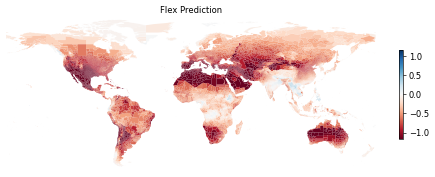

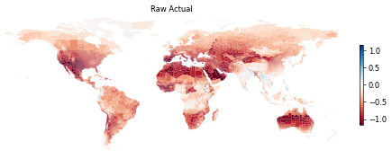

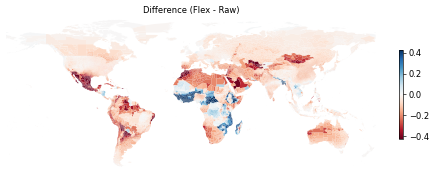

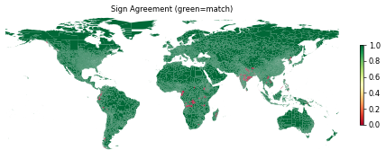

[interactive chart not shown]

Top 5 best predicted Top 5 worst predicted

Year 2098 · T<sub>mean</sub> across these regions: 4.51°C

| Region | Raw | Flex | Residual |
| --- | --- | --- | --- |
| FJI.R13886963f95ae1bc | 0 | 0 | 0 |
| TUV.R06fb643237e8113e | 0 | 0 | 0 |
| USA.2.71 | -0.324 | -0.324 | -3.43e-6 |
| THA.3.R54a58ba78ac1fc58 | 0.0173 | 0.0173 | -4.63e-5 |
| PHL.1 | -0.209 | -0.209 | -7.40e-5 |
| ISR.5 | -0.63 | -1.63 | -1 |
| ISR.2 | -0.6 | -1.57 | -0.969 |
| GIN.1.2.17 | -1.47 | -0.573 | 0.892 |
| GIN.1.2.11 | -1.46 | -0.572 | 0.887 |
| GIN.1.2.13 | -1.46 | -0.587 | 0.869 |

**SSP4**

**high**

**Correlation:** 0.9304 | **RMSE:** 0.138886 | **Sign agreement:** 97.5%

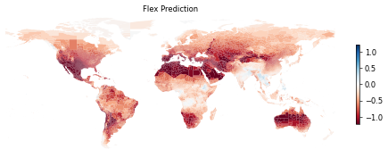

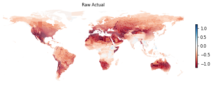

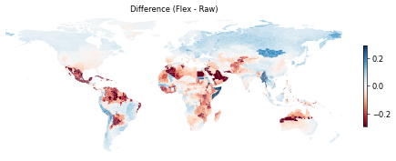

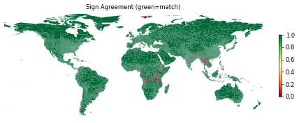

[interactive chart not shown]

Top 5 best predicted Top 5 worst predicted

Year 2098 · T<sub>mean</sub> across these regions: 4.51°C

| Region | Raw | Flex | Residual |
| --- | --- | --- | --- |
| FJI.R13886963f95ae1bc | 0 | 0 | 0 |
| TUV.R06fb643237e8113e | 0 | 0 | 0 |
| FRA.73.82 | -1.19 | -1.19 | 1.10e-5 |
| IND.12.134.481 | -0.366 | -0.366 | -1.77e-5 |
| AUS.4.R874d7ca7a97764c3 | -0.714 | -0.714 | -2.22e-5 |
| SOM.1.R472bf830dca32de3 | -1.84 | -0.617 | 1.22 |
| SOM.1.1 | -1.78 | -0.636 | 1.15 |
| SOM.7.29 | -1.55 | -0.481 | 1.07 |
| SOM.2.6 | -1.6 | -0.538 | 1.06 |
| SOM.8.Rfccc5a812678586e | -1.59 | -0.53 | 1.06 |

**low**

**Correlation:** 0.9532 | **RMSE:** 0.136844 | **Sign agreement:** 97.5%

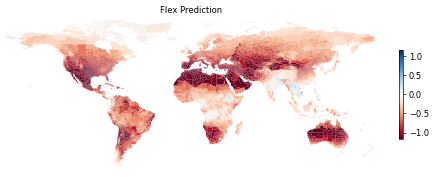

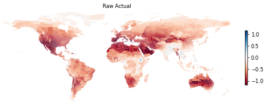

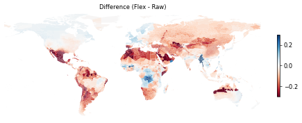

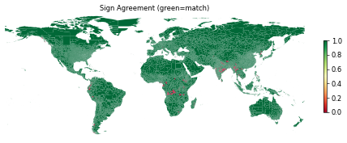

[interactive chart not shown]

Top 5 best predicted Top 5 worst predicted

Year 2098 · T<sub>mean</sub> across these regions: 4.51°C

| Region | Raw | Flex | Residual |
| --- | --- | --- | --- |
| FJI.R13886963f95ae1bc | 0 | 0 | 0 |
| TUV.R06fb643237e8113e | 0 | 0 | 0 |
| IND.21.330.1371 | -0.344 | -0.344 | -1.74e-6 |
| NGA.19.350 | -0.313 | -0.313 | -2.92e-6 |
| IND.33.511.2064 | -0.132 | -0.132 | -3.29e-6 |
| AUS.11.1302 | -0.603 | -1.55 | -0.952 |
| AUS.11.1376 | -0.606 | -1.55 | -0.948 |
| AUS.11.1276 | -0.579 | -1.5 | -0.924 |
| AUS.5.386 | -0.64 | -1.54 | -0.904 |
| AUS.6.606 | -0.598 | -1.47 | -0.872 |

**Note · countries with no cassava data** (shown white on every map above; the GCP cassava pipeline does not run sims for non-producing countries): ATA, BVT, CL-, HMD, IOT, SGS, SP-.

## 10.1 Scenario Summary

Table 7: Fit statistics across all 12 scenarios

| RCP | SSP | Model | N | Corr | RMSE | Sign% |
| --- | --- | --- | --- | --- | --- | --- |
| rcp45 | SSP2 | high | 24,326 | 0.9051 | 0.082758 | 95.3% |
| rcp45 | SSP2 | low | 24,326 | 0.9338 | 0.071345 | 95.8% |
| rcp45 | SSP3 | high | 24,326 | 0.9415 | 0.082191 | 95.0% |
| rcp45 | SSP3 | low | 24,326 | 0.9029 | 0.090897 | 95.9% |
| rcp45 | SSP4 | high | 24,326 | 0.9149 | 0.078364 | 95.9% |
| rcp45 | SSP4 | low | 24,326 | 0.9392 | 0.073116 | 95.1% |
| rcp85 | SSP2 | high | 24,326 | 0.9553 | 0.111964 | 96.9% |
| rcp85 | SSP2 | low | 24,326 | 0.9617 | 0.105803 | 98.0% |
| rcp85 | SSP3 | high | 24,326 | 0.9725 | 0.164938 | 97.3% |
| rcp85 | SSP3 | low | 24,326 | 0.9066 | 0.179132 | 96.8% |
| rcp85 | SSP4 | high | 24,326 | 0.9304 | 0.138886 | 97.5% |
| rcp85 | SSP4 | low | 24,326 | 0.9532 | 0.136844 | 97.5% |

# 11 Data Reference

## 11.1 File Locations

| Item | Path |
| --- | --- |
| Regional CSV | `/project/cil/gcp/flex_damage_funcs/parameters/agriculture__cassava__regional_parameters.csv` |
| Global JSON | `/project/cil/gcp/flex_damage_funcs/parameters/agriculture__cassava__global_results.json` |
| Metadata JSON | `/project/cil/gcp/flex_damage_funcs/parameters/agriculture__cassava__metadata.json` |

## 11.2 Column Definitions

| Column | Description |
| --- | --- |
| `region` | Region identifier (hierarchical code, first 3 chars = country ISO3) |
| `gamma` | Income elasticity quantile value |
| `alpha` | Linear temperature coefficient |
| `beta` | Quadratic temperature coefficient |
| `sigma11` | Var(alpha) |
| `sigma12` | Cov(alpha, beta) |
| `sigma22` | Var(beta) |
| `rho` | Correlation with global residual process |
| `zeta` | Temperature-dependent heteroskedasticity |
| `eta` | Residual standard deviation |
| `rsqr1` | R-squared of polynomial fit |
| `rsqr2` | R-squared of error model |

*Report generated with FlexDamage v1.0.0*